# ACP5 EERES-Pond-Model

Moritz Berg, Luic Damian

2025-03-19

# Task

**Validation of the models against observational data. Random and Systematic Discrepancies.**

Note: When answering the above-mentioned research questions, the focus should be on the methodological aspects of the respective model applications and the necessary analyses. A detailed answer to the questions in the context of other scientific work goes beyond the scope of this course.

Portfolio: Description of methods, results and a (short) discussion. The important thing is the complete documentation of the conducted model simulations.

## Data Preparation

The required format of data for the LakeEnsemblR model environment are *.csv* tables containing the pond hypsograph, the water temperature profile of the pond and the meteorological data. These files are prepared using the following code from the given datasets.

## Observed Data Preparation

```r
# turn wide format of EERES Temperature to long format
EERES_Temperature = read_csv("Data/EERES_Temperature.csv")
EERES_T_long = pivot_longer(EERES_Temperature, cols=`30 cm`:`air`, names_to = "Depth_meter", values_to = "Water_Temperature_celsius") %>%
  filter(!Depth_meter=="air") %>%
  mutate(datetime = dmy_hm(time),
         Depth_meter =  gsub("[^0-9]", "", Depth_meter)) %>%
  mutate(Depth_meter = as.numeric(Depth_meter)/100) %>%
  select(-time) %>%
  select(datetime, Depth_meter, Water_Temperature_celsius) %>%
  filter(!is.na(Water_Temperature_celsius)) %>%
  mutate(datetime = format(floor_date(as_datetime(datetime), unit="10 minutes"),"%Y-%m-%d %H:%M:%S"))

# Optionally discard the Temperature at 15cm depth due to missing data
# EERES_T_dropNAcol = EERES_T_long %>%
#   filter(Depth_meter!=0.15)
```

## Interpolation of missing data

To fill the observations the missing data at the depth of 15cm is interpolated from the temperature observations 5cm above and below. This can be subsequentially used if required by the models.

```r
#### interpolation of missing data at 15cm depth ####
#### from adjacent depths                        ####

# Function to interpolate temperature for NA values at Depth_meter = 0.15
interpolate_na_temperature <- function(data) {
  # Filter for the specific datetime and depth
  temp_data <- data %>% filter(Depth_meter %in% c(0.1, 0.2) & !is.na(Water_Temperature_celsius))

  if (nrow(temp_data) == 2) {
    # Perform linear interpolation
    interpolated_temp <- approx(temp_data$Depth_meter, temp_data$Water_Temperature_celsius, xout = 0.15)$y
    return(interpolated_temp)
  } else {
    return(NA)  # Return NA if not enough data for interpolation
  }
}

# Apply interpolation only for NA values at Depth_meter = 0.15
EERES_T_long <- EERES_T_long %>%
  group_by(datetime) %>%
  mutate(Water_Temperature_celsius = ifelse(Depth_meter == 0.15 & is.na(Water_Temperature_celsius),
                                             interpolate_na_temperature(cur_data()),
                                             Water_Temperature_celsius)) %>%
  ungroup()


#### write water temperature to .csv file ####

# write.table(EERES_T_long, file = "LakeEnsemblR_wtemp_profile_EERES.csv", sep = ",", dec = ".", row.names = FALSE, col.names = TRUE, quote = FALSE)

# write.table(EERES_T_dropNAcol, file = "LakeEnsemblR_wtemp_profile_EERES.csv", sep = ",", dec = ".", row.names = FALSE, col.names = TRUE, quote = FALSE)
```

## Meteo Data Preparation

Following code presents the preparation of the meteorological data. This was done by aggregating the meteorological data to the temporal scale of the observed data (1min to 10min). Therefore averaging the parameters and summing of the parameter rainfall in mm per hour was applied. LakeEnsemblR requires an input of surface level barometric pressure in Pa, therefore the transformation from hPa tp Pa was undertaken. The wind direction and speed at 10m above surface is required for the meteorolgical forcing data. The exact location of the anemometer was not known, hence it was assumed that the given data reflects this requirement.

```r
#### Loading meteorological data ####

meteo_raw = read_xlsx("Data/20200101-20211231_Wetterstationsdaten_Andreas Lorke.xlsx",
    skip = 1, na=c("-99999.9","-9999"))
meteo = meteo_raw %>%
  as.data.frame() %>%
  mutate(across(where(is.numeric), ~ na_if(., -9999))) %>%      # NAs
  mutate(across(where(is.numeric), ~ na_if(., -99999.9))) %>%   # NAs
  mutate(time=format(as_datetime(`~...1`),"%H:%M:%S"),
         date=format(as_datetime(`~...2`),"%Y-%m-%d")) %>%
  mutate(datetime=ymd(date) + hms(time))

# check for na values in all columns but the wind direction column WV
na_df <- meteo %>%
  select(SO,TE,FE,TP,WD,WR,RD,DR,RE) %>%
  filter(if_any(everything(), is.na))


#### Aggregating the meteorological data to 10 minute intervals ####

meteo_10m_t = meteo %>%
  # Melt the data to long format
  pivot_longer(cols = -c(datetime,`~...1`,`~...2`,time,date), names_to = "variable", values_to = "value") %>%
  # Create time groups by flooring the datetime to 10minute sets
  mutate(time_group = floor_date(datetime, unit = "10 minutes")) %>%
  # Group by time_group and variable
  group_by(time_group, variable) %>%
  # Summarise the data to ensure a single value per group
  summarise(value = ifelse(variable == "RD", sum(value, na.rm = TRUE), mean(value, na.rm = TRUE)),
            .groups = "drop") %>%
  # Gather back to wide format, ensuring unique values
  pivot_wider(names_from = variable, values_from = value, values_fn = list(value = mean))
#### Adding missing time steps for proper model functioning ####

# fill missing steps in time series of meteo data
complete_time_series <- seq(from = min(meteo_10m_t$time_group, na.rm = TRUE),
                  to = max(meteo_10m_t$time_group, na.rm = TRUE),
                  by = "10 min")

meteo_complete <- data.frame(time_group=complete_time_series) %>%
  full_join(meteo_10m_t, by = "time_group")

meteo_filled <- meteo_complete %>%
#interpolate values
  mutate(across(-c(time_group, WV), ~ zoo::na.approx(.))) %>%
  select(time_group,SO,TE,FE,TP,WD,WR,RD,DR) %>%
#hPa to Pa
  mutate(DR = 100*DR) %>%
#mm/10min to mm/hr
  mutate(RD = 6*RD) %>%
#rename and restructure to LakeEnsemblR Standard
  rename(datetime=time_group,
  Shortwave_Radiation_Downwelling_wattPerMeterSquared=SO,
  Air_Temperature_celsius=TE,
  Relative_Humidity_percent=FE,
  Dewpoint_Temperature_celsius=TP,
  Ten_Meter_Elevation_Wind_Speed_meterPerSecond=WD,
  Ten_Meter_Elevation_Wind_Direction_degree=WR,
  Rainfall_millimeterPerHour=RD,
  Surface_Level_Barometric_Pressure_pascal=DR) %>%
  mutate(datetime = format(datetime, "%Y-%m-%d %H:%M:%S")) %>%
  select(datetime,Ten_Meter_Elevation_Wind_Speed_meterPerSecond,Air_Temperature_celsius,Relative_Humidity_percent,Shortwave_Radiation_Downwelling_wattPerMeterSquared,Surface_Level_Barometric_Pressure_pascal,Rainfall_millimeterPerHour)

# check for remaining NAs
meteo_filled %>%
  filter(if_any(everything(), is.na))
```

```
## [1] datetime
## [2] Ten_Meter_Elevation_Wind_Speed_meterPerSecond
## [3] Air_Temperature_celsius
## [4] Relative_Humidity_percent
## [5] Shortwave_Radiation_Downwelling_wattPerMeterSquared
## [6] Surface_Level_Barometric_Pressure_pascal
## [7] Rainfall_millimeterPerHour
## <0 Zeilen> (oder row.names mit Länge 0)
```

```r
# check for missing time steps
all(meteo_filled$time_group == complete_time_series)
```

```
## [1] TRUE
```

```r
#### write meteorological data to .csv file ####

# write.table(meteo_filled, file = "LakeEnsemblR_meteo_EERES.csv", sep = ",", dec = ".", row.names = FALSE, col.names = TRUE, quote = FALSE)
```

The configuration template was loaded into the working directory.

# Model

## Ensemble model run

Following Code runs the LER model using a default calibration of the model parameters.

There are issues using GLM and MyLake in shallow ponds, therefore all following simulations are done using exclusively FLake, GOTM or Simstrat.

We found that the model FLake calculates a mean depth of the lake from the volume (calculated from truncated square pyramids between the layers) and the surface area. This however seems to reduce the depth of shallow ponds below the depths of observed layers. Therefore we manually set the depth of the pond for FLake using the parameter `depth_w_lk`.

```r
#### ensure the working directory is properly set ####

getwd()
# setwd("../")
# Set config file & models
config_file <- "LakeEnsemblR_EERES.yaml"
# model <- c("FLake", "GLM", "GOTM", "Simstrat",  "MyLake")
model <- c("FLake","GOTM","Simstrat")



#### Create configuration and run LER ####

# Default run
# 1. Export settings - creates directories with all model setups and exports settings from the LER configuration file
export_config(config_file = config_file, model = model)

# 2. Run ensemble lake models
run_ensemble(config_file = config_file, model = model, parallel = T, return_list = T, ncores = 3, verbose=F)

# Optionally check configuration
# check_master_config(config_file= config_file, model=model, exp_cnf = T)
```

## Calibration

The calibration is done using the function `cali_ensemble`. Due to errors by using this function on all models simultaneously, the results will be generated for each model individually For each model, a calibration using a set of 500 parameter combinations is used for the models Simstrat and GOTM. For FLake only 100 parameter combinations were used due to technical obstacles. A Latin Hypercube Calibration (LHC) method is used in the calibration. With the function `plot_LHC`, the results can be shown graphically.

Depending on some arguments given to `cali_ensemble` (we guess `parallel = True`), the output of the function will either be the results or the names of the .csv files which store the parameter sets and results. Due to this inconsistency in the code, we manually select the generated results from the folder /*cali*.

```r
#### Function to retrieve model fit ####

# getting the model fit of the last ensemble run
calc_fit(ncdf = "output/ensemble_output.nc", model = model)
```

```
## $FLake
##       rmse       nse         r      bias     mae      nmae
## 1 4.339755 0.4774349 0.8561643 -2.915374 3.68692 0.4528486
##
## $GOTM
##       rmse       nse         r     bias      mae      nmae
## 1 3.656275 0.6802949 0.9762204 -3.35578 3.365375 0.5341126
##
## $Simstrat
##       rmse      nse         r     bias      mae      nmae
## 1 2.206687 0.871688 0.9697002 -1.55749 1.805663 0.2938269
##
## $ensemble_mean
##       rmse       nse         r      bias      mae      nmae
## 1 3.291882 0.6993772 0.9349666 -2.467639 2.851131 0.3849892
```

```
## $GOTM
## $GOTM$wind_speed
```

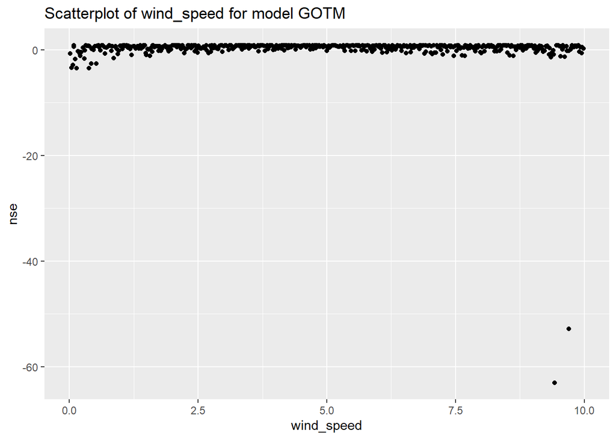

```
##
## $GOTM$dist_wind_speed
```

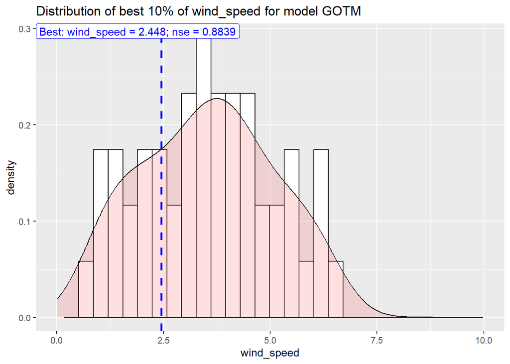

```
##
## $GOTM$swr
```

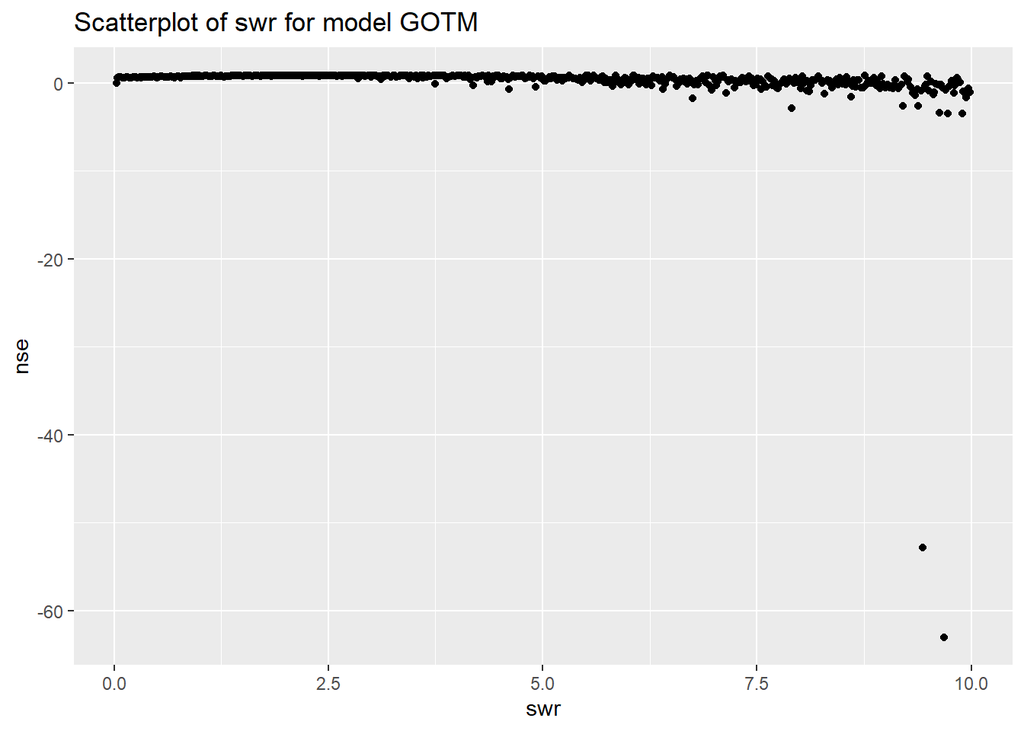

```
##
## $GOTM$dist_swr
```

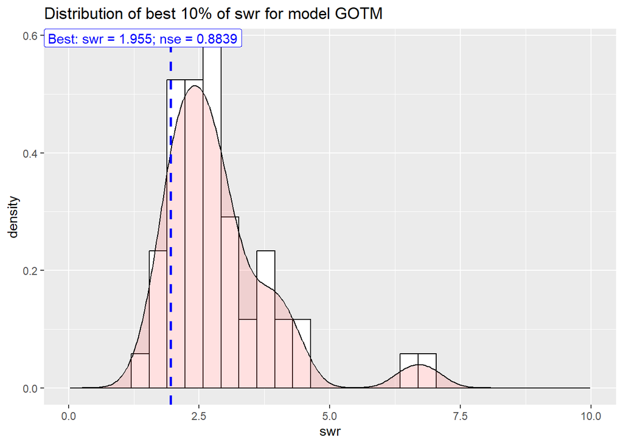

```
##
## $GOTM$Kw
```

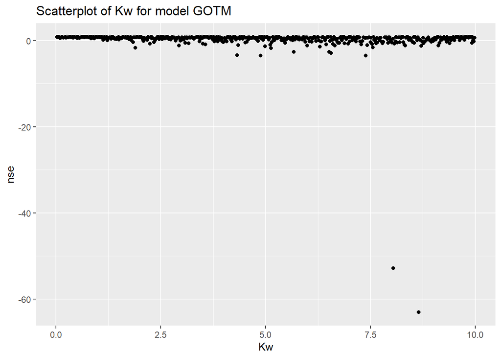

```
##
## $GOTM$dist_Kw
```

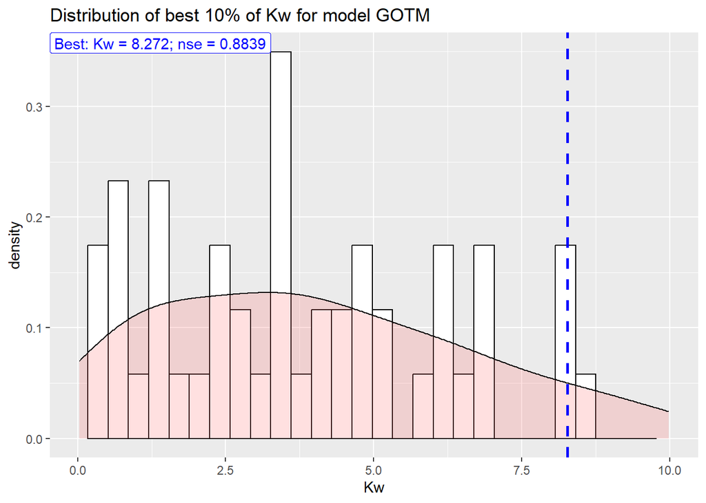

```
##
## $GOTM$turb_param.k_min
```

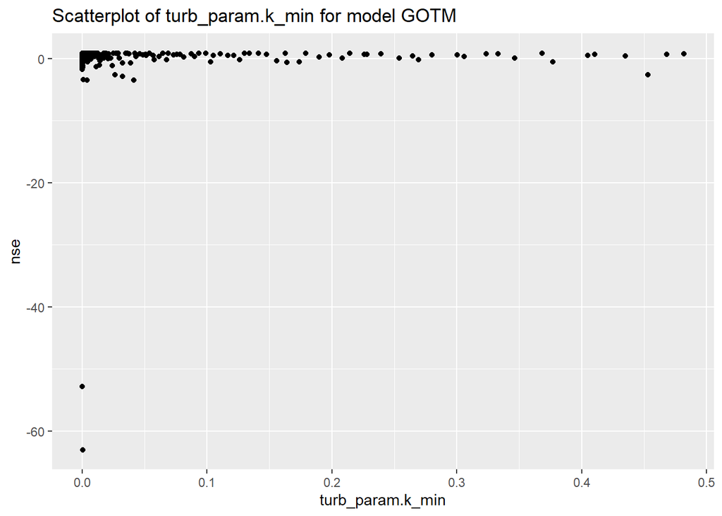

```
##
## $GOTM$dist_turb_param.k_min
```

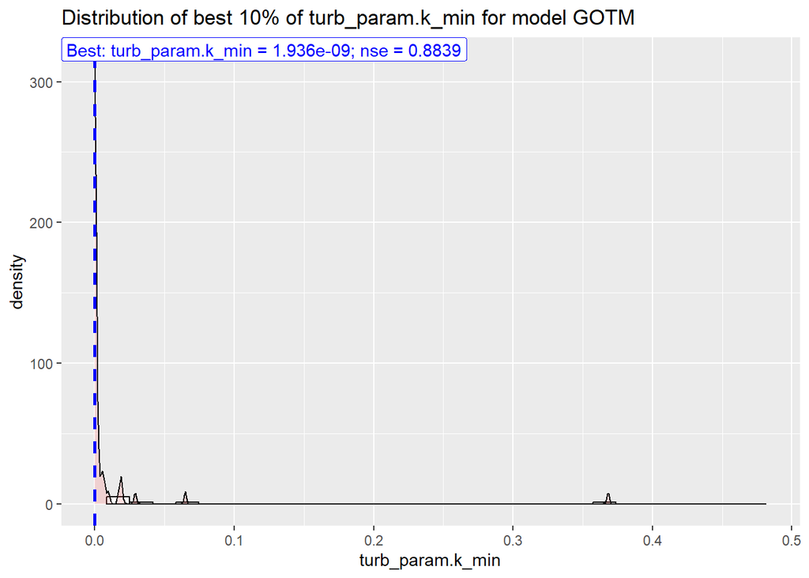

```r
#### Running the calibration for each model ####

#config_file = "LakeEnsemblR_EERES_calibration.yaml"
#
# # run the calibration using the LHC method
# cali_res_Simstrat <- cali_ensemble(config_file = config_file, num = 500, cmethod = "LHC",
#                           parallel = T, model = "SimStrat", ncores = 3)
# cali_res_GOTM <- cali_ensemble(config_file = config_file, num = 30, cmethod = "LHC",
#                           parallel = T, model = "GOTM", ncores = 3)
# cali_res_FLake <- cali_ensemble(config_file = config_file, num = 30, cmethod = "LHC",
#                           parallel = T, model = "FLake", ncores = 3)

# we manually set the file names with the results
res_file_GOTM <- paste0(getwd(),
                            c("/cali/params_GOTM_LHC_n500.csv",
                              "/cali/GOTM_LHC_n500.csv"))
res_file_FLake <- paste0(getwd(),
                            c("/cali/params_FLake_LHC_n100.csv",
                              "/cali/FLake_LHC_n100.csv"))
res_file_Simstrat <- paste0(getwd(),
                            c("/cali/params_Simstrat_LHC_n500.csv",
                              "/cali/Simstrat_LHC_n500.csv"))



#### Plotting the  calibration results ####

plot_LHC(config_file = config_file, model = "GOTM", res_files = res_file_GOTM,
         qual_met = "nse", best = "high")
```

```
## $Simstrat
## $Simstrat$wind_speed
```

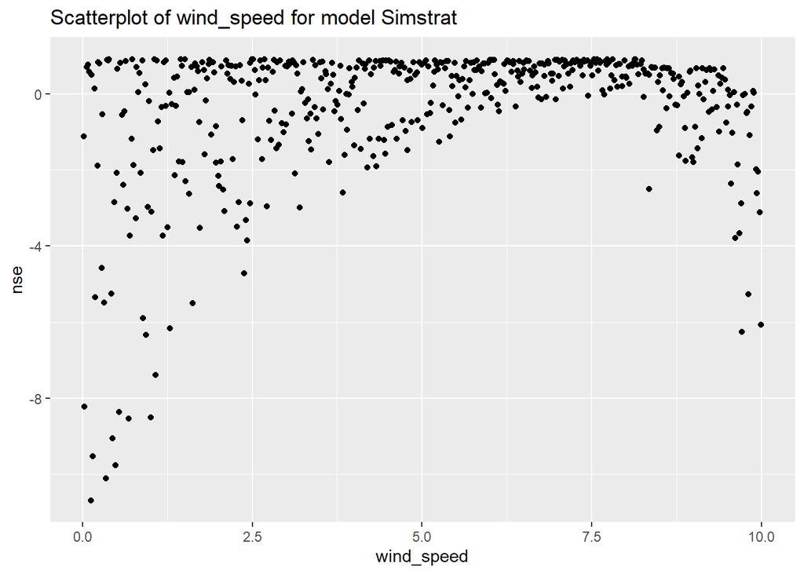

```
##
## $Simstrat$dist_wind_speed
```

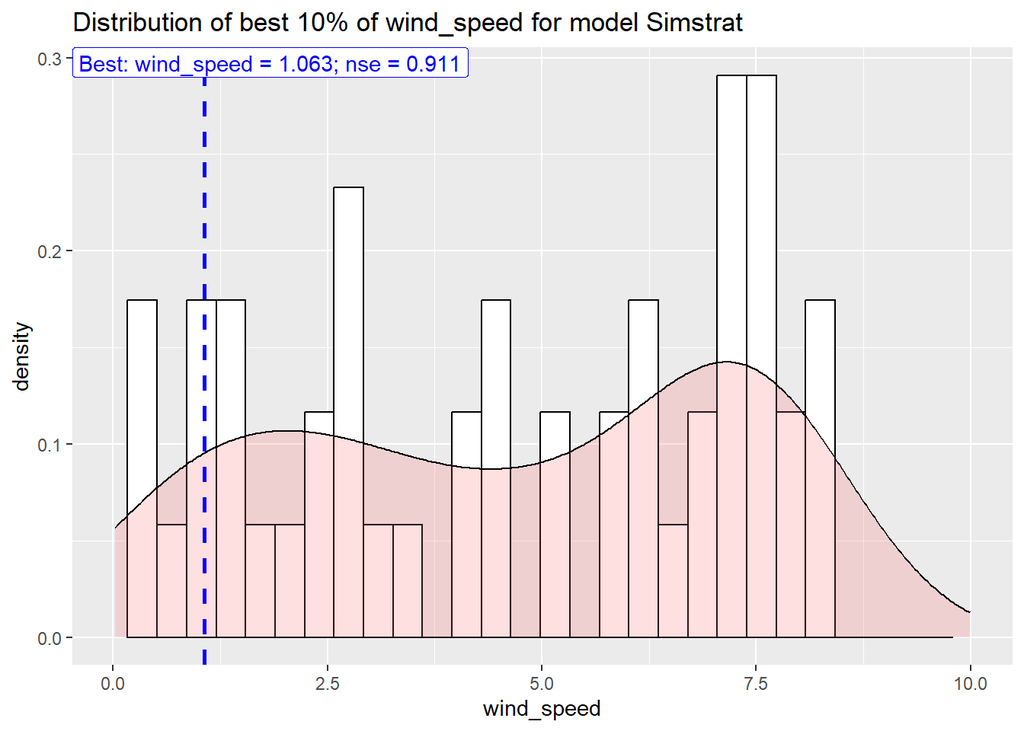

```
##
## $Simstrat$swr
```

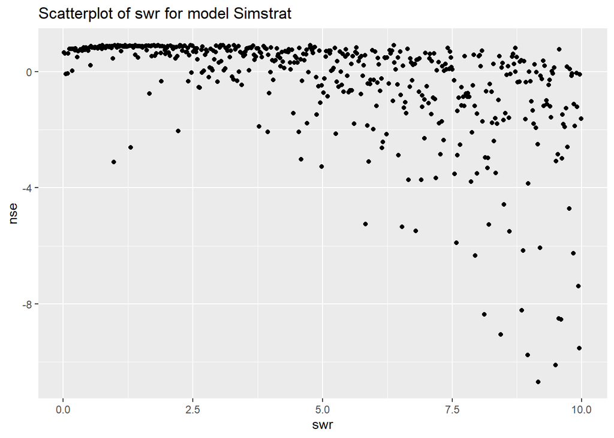

```
##
## $Simstrat$dist_swr
```

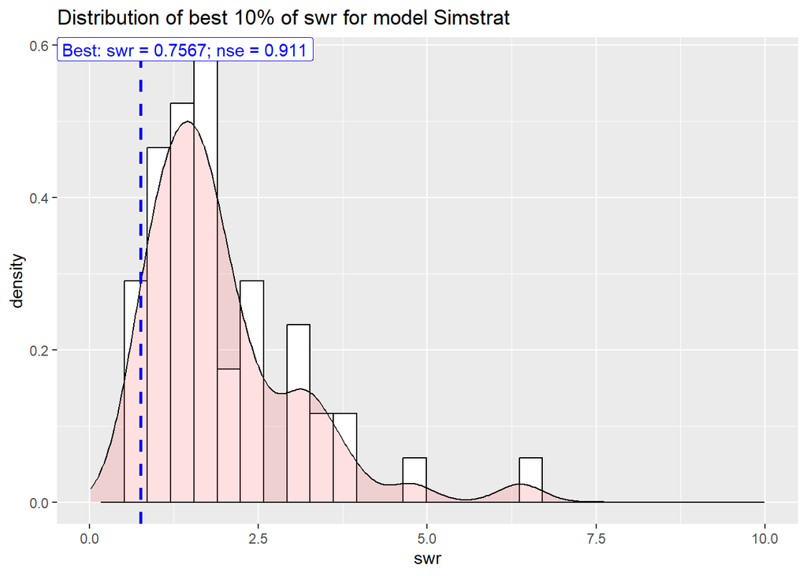

```
##
## $Simstrat$Kw
```

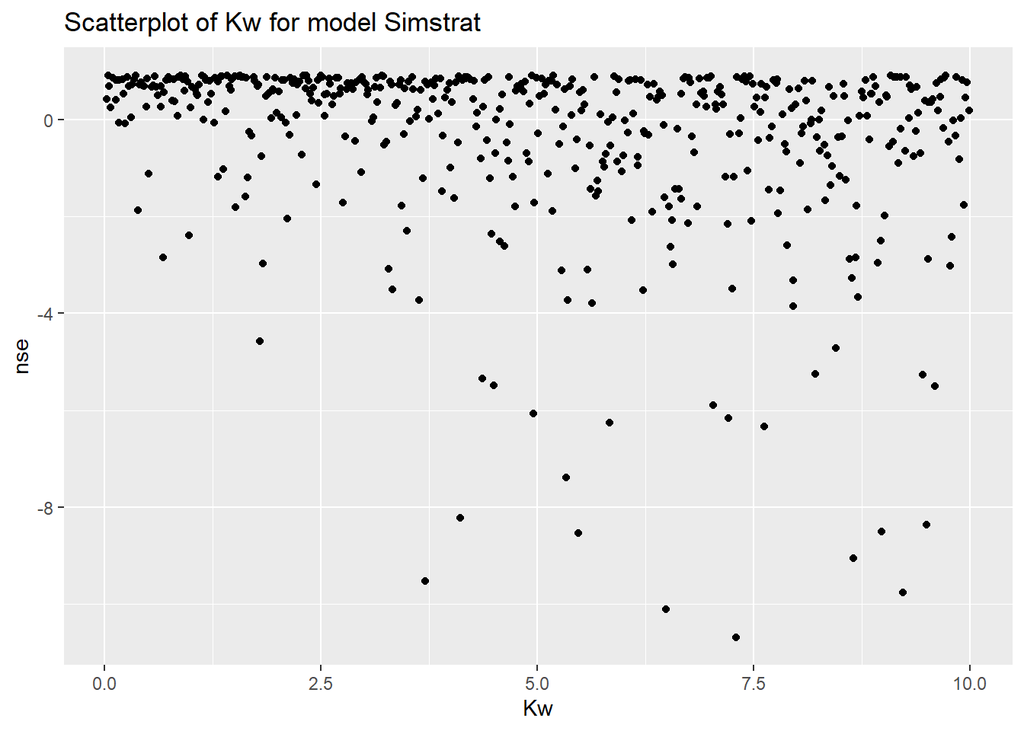

```
##
## $Simstrat$dist_Kw
```

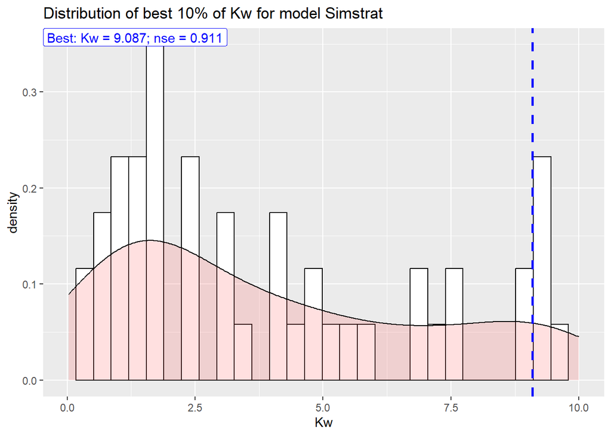

```
##
## $Simstrat$a_seiche
```

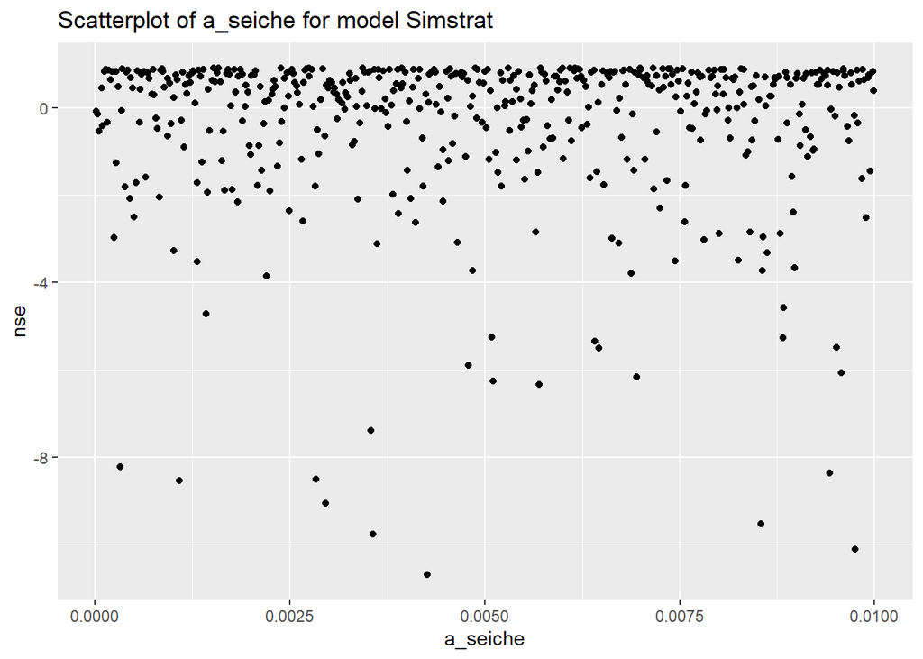

```
##
## $Simstrat$dist_a_seiche
```

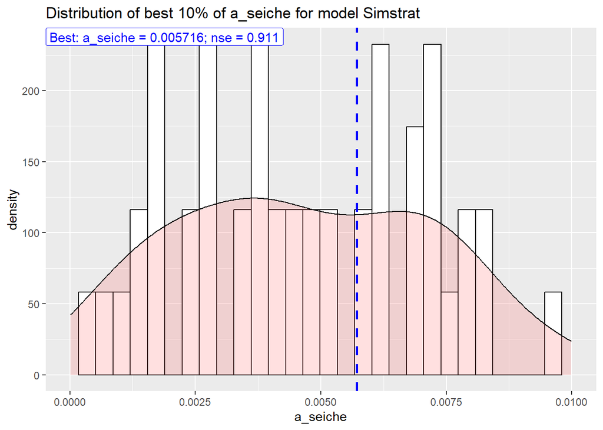

```r
# the plotting of FLake is sometimes not possible due to bugs
# plot_LHC(config_file = config_file, model = "FLake", res_files = res_file_FLake,
#          qual_met = "nse", best = "high")
plot_LHC(config_file = config_file, model = "SimStrat", res_files = res_file_Simstrat,
         qual_met = "nse", best="high")
```

Since the inherent method of using a single model perfomance metric to derive the set of parameters with the best performance is rather arbitrary, we decided to develop a more systematic approach to identify the model parameters with the best fit.

The simulations using different sets of parameters were subsequently analyzed, aiming to identify parameter values which minimize deviations from observed data. For this purpose a composite error metric combining RMSE, NSE, Bias and R² was calculated. Parameter values which minimized this composite score were chosen as the calibrated value.

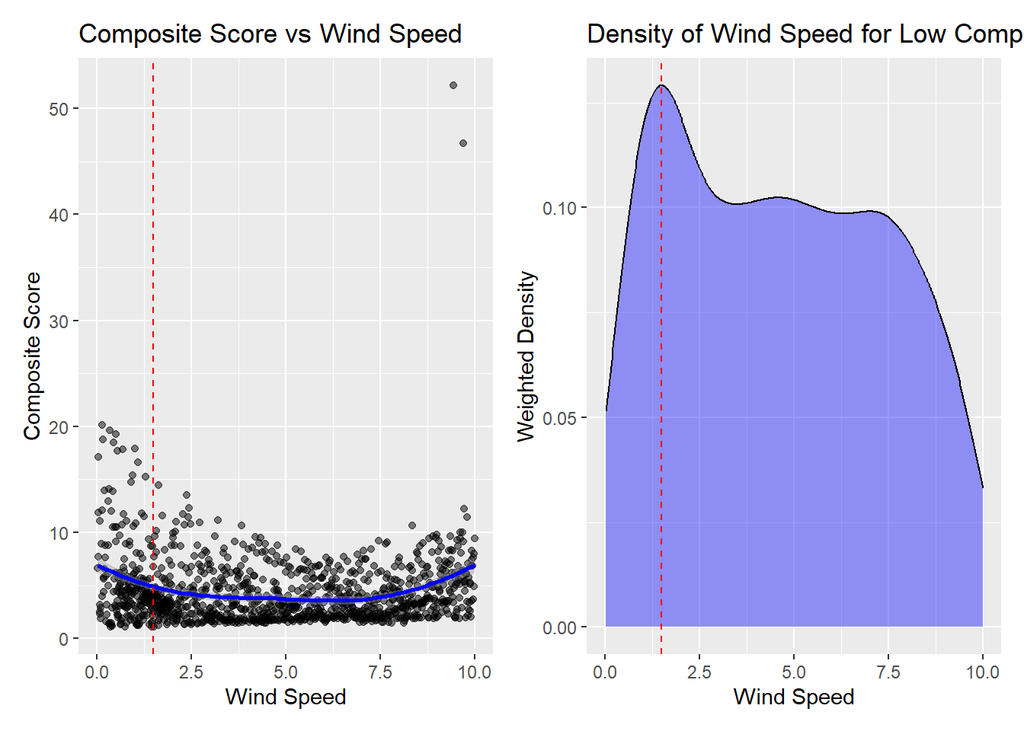

```r
params_Sim = read.csv("cali/params_Simstrat_LHC_n500.csv")
em_Sim = read.csv("cali/Simstrat_LHC_n500.csv")

params_GOTM = read.csv("cali/params_GOTM_LHC_n500.csv")
em_GOTM = read.csv("cali/GOTM_LHC_n500.csv")

params_FLake = read.csv("cali/params_FLake_LHC_n100.csv")
em_FLake = read.csv("cali/FLake_LHC_n100.csv")

join_Sim = full_join(params_Sim, em_Sim, by = "par_id")
join_GOTM = full_join(params_GOTM, em_GOTM, by = "par_id")
join_FLake = full_join(params_FLake, em_FLake, by = "par_id")


## Merge data sets for calibration of shared parameters
Sim_red = join_Sim %>% select(-a_seiche, -par_id)
GOTM_red = join_GOTM %>% select(-turb_param.k_min, -par_id)
FLake_red = join_FLake %>% select(-c_relax_C, -par_id)

shared = rbind(Sim_red, GOTM_red, FLake_red)



#### Calculate composite error metric score ####

## Weights (scaled with standard deviation to approximate equal influence of individual metrics)
w1 = 1/sd(join_Sim$rmse) # RMSE
w2 = 1/sd((1-join_Sim$nse)) # NSE
w3 = 1/sd(abs(join_Sim$bias)) # Bias
w4 = 1/sd(1- join_Sim$r) # R^2

## Compisite error metric
join_Sim$score = w1*join_Sim$rmse + w2*(1-join_Sim$nse) + w3*abs(join_Sim$bias) + w4*(1- join_Sim$r)


## Weights (scaled with standard deviation to approximate equal influence of individual metrics)
w5 = 1/sd(join_GOTM$rmse) # RMSE
w6 = 1/sd((1-join_GOTM$nse)) # NSE
w7 = 1/sd(abs(join_GOTM$bias)) # Bias
w8 = 1/sd(1- join_GOTM$r) # R^2

## Compisite error metric
join_GOTM$score = w5*join_GOTM$rmse + w6*(1-join_GOTM$nse) + w7*abs(join_GOTM$bias) + w8*(1- join_GOTM$r)


## Weights (scaled with standard deviation to approximate equal influence of individual metrics)
w9 = 1/sd(join_FLake$rmse) # RMSE
w10 = 1/sd((1-join_FLake$nse)) # NSE
w11 = 1/sd(abs(join_FLake$bias)) # Bias
w12 = 1/sd(1- join_FLake$r) # R^2

## Compisite error metric
join_FLake$score = w9*join_FLake$rmse + w10*(1-join_FLake$nse) + w11*abs(join_FLake$bias) + w12*(1- join_FLake$r)


## Weights (scaled with standard deviation to approximate equal influence of individual metrics)
w13 = 1/sd(shared$rmse) # RMSE
w14 = 1/sd((1-shared$nse)) # NSE
w15 = 1/sd(abs(shared$bias)) # Bias
w16 = 1/sd(1- shared$r) # R^2

## Compisite error metric
shared$score = w13*shared$rmse + w14*(1-shared$nse) + w15*abs(shared$bias) + w16*(1- shared$r)

##### Shared model parameters #####

## Wind speed

# Extract the computed density data from ggplot
dens_data <- ggplot_build(
  ggplot(shared, aes(x = wind_speed)) +
    geom_density(aes(weight = 1 / score), fill = "blue", alpha = 0.4)
)$data[[1]]

# Find wind speed where density is maximized
optimal_wind_speed <- dens_data$x[which.max(dens_data$y)]




a_ws = ggplot(shared, aes(x = wind_speed, y = score)) +
  geom_point(alpha = 0.5) +
  geom_smooth(method = "loess", color = "blue") +
  geom_vline(xintercept = optimal_wind_speed, color = "red", linetype = "dashed") +
  labs(title = "Composite Score vs Wind Speed",
       x = "Wind Speed",
       y = "Composite Score")

b_ws = ggplot(shared, aes(x = wind_speed)) +
  geom_density(aes(weight = 1 / score), fill = "blue", alpha = 0.4) +
  geom_vline(xintercept = optimal_wind_speed, color = "red", linetype = "dashed") +
  labs(title = "Density of Wind Speed for Low Composite Score",
       x = "Wind Speed",
       y = "Weighted Density")

a_ws+b_ws
```

```r
## Optimal wind speed
print(optimal_wind_speed)
```

```
## [1] 1.495386
```

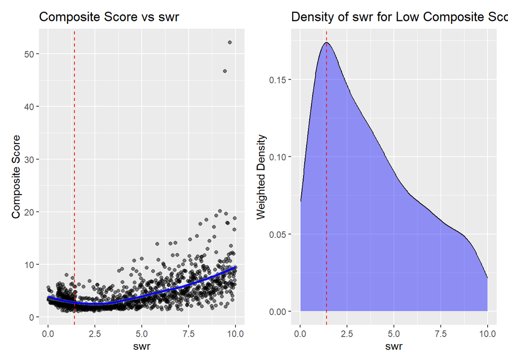

```r
## SWR
# Extract the computed density data from ggplot
dens_data <- ggplot_build(
  ggplot(shared, aes(x = swr)) +
    geom_density(aes(weight = 1 / score), fill = "blue", alpha = 0.4)
)$data[[1]]

# Find wind speed where density is maximized
optimal_swr <- dens_data$x[which.max(dens_data$y)]


a_swr = ggplot(shared, aes(x = swr, y = score)) +
  geom_point(alpha = 0.5) +
  geom_smooth(method = "loess", color = "blue") +
  geom_vline(xintercept = optimal_swr, color = "red", linetype = "dashed") +
  labs(title = "Composite Score vs swr",
       x = "swr",
       y = "Composite Score")

b_swr = ggplot(shared, aes(x = swr)) +
  geom_density(aes(weight = 1 / score), fill = "blue", alpha = 0.4) +
  geom_vline(xintercept = optimal_swr, color = "red", linetype = "dashed") +
  labs(title = "Density of swr for Low Composite Score",
       x = "swr",
       y = "Weighted Density")

a_swr+b_swr
```

```r
print(optimal_swr)
```

```
## [1] 1.403216
```

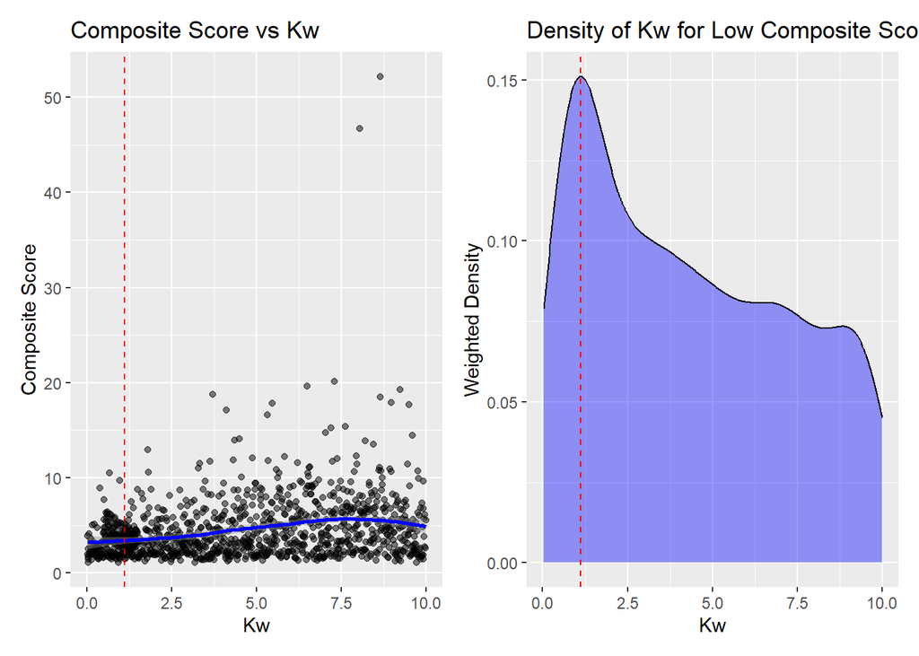

```r
## Kw
# Extract the computed density data from ggplot
dens_data <- ggplot_build(
  ggplot(shared, aes(x = Kw)) +
    geom_density(aes(weight = 1 / score), fill = "blue", alpha = 0.4)
)$data[[1]]

# Find wind speed where density is maximized
optimal_Kw <- dens_data$x[which.max(dens_data$y)]


a_Kw = ggplot(shared, aes(x = Kw, y = score)) +
  geom_point(alpha = 0.5) +
  geom_smooth(method = "loess", color = "blue") +
  geom_vline(xintercept = optimal_Kw, color = "red", linetype = "dashed") +
  labs(title = "Composite Score vs Kw",
       x = "Kw",
       y = "Composite Score")

b_Kw = ggplot(shared, aes(x = Kw)) +
  geom_density(aes(weight = 1 / score), fill = "blue", alpha = 0.4) +
  geom_vline(xintercept = optimal_Kw, color = "red", linetype = "dashed") +
  labs(title = "Density of Kw for Low Composite Score",
       x = "Kw",
       y = "Weighted Density")

a_Kw+b_Kw
```

```r
print(optimal_Kw)
```

```
## [1] 1.119239
```

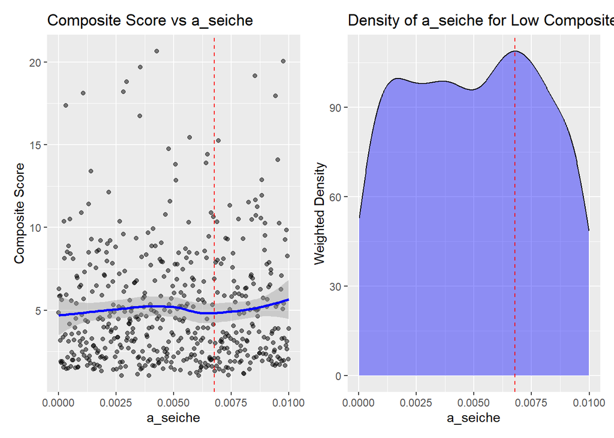

```r
#### Model specific parameters ####

  ##### Simstrat #####

    ## a_seiche
    # Extract the computed density data from ggplot
    dens_data <- ggplot_build(
      ggplot(join_Sim, aes(x = a_seiche)) +
        geom_density(aes(weight = 1 / score), fill = "blue", alpha = 0.4)
    )$data[[1]]

    # Find wind speed where density is maximized
    optimal_a_seiche <- dens_data$x[which.max(dens_data$y)]


    a_a_seiche = ggplot(join_Sim, aes(x = a_seiche, y = score)) +
      geom_point(alpha = 0.5) +
      geom_smooth(method = "loess", color = "blue") +
      geom_vline(xintercept = optimal_a_seiche, color = "red", linetype = "dashed") +
      labs(title = "Composite Score vs a_seiche",
           x = "a_seiche",
           y = "Composite Score")

    b_a_seiche = ggplot(join_Sim, aes(x = a_seiche)) +
      geom_density(aes(weight = 1 / score), fill = "blue", alpha = 0.4) +
      geom_vline(xintercept = optimal_a_seiche, color = "red", linetype = "dashed") +
      labs(title = "Density of a_seiche for Low Composite Score",
           x = "a_seiche",
           y = "Weighted Density")

    a_a_seiche+b_a_seiche
```

```r
    print(optimal_a_seiche)
```

```
## [1] 0.006769829
```

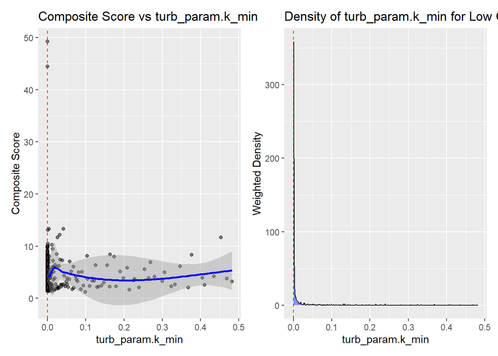

```r
  ##### GOTM #####

    ## turb_param.k_min
    # Extract the computed density data from ggplot
    dens_data <- ggplot_build(
      ggplot(join_GOTM, aes(x = turb_param.k_min)) +
        geom_density(aes(weight = 1 / score), fill = "blue", alpha = 0.4)
    )$data[[1]]

    # Find wind speed where density is maximized
    optimal_turb_param.k_min <- dens_data$x[which.max(dens_data$y)]


    a_turb_param.k_min = ggplot(join_GOTM, aes(x = turb_param.k_min, y = score)) +
      geom_point(alpha = 0.5) +
      geom_smooth(method = "loess", color = "blue") +
      geom_vline(xintercept = optimal_turb_param.k_min, color = "red", linetype = "dashed") +
      labs(title = "Composite Score vs turb_param.k_min",
           x = "turb_param.k_min",
           y = "Composite Score")

    b_turb_param.k_min = ggplot(join_GOTM, aes(x = turb_param.k_min)) +
      geom_density(aes(weight = 1 / score), fill = "blue", alpha = 0.4) +
      geom_vline(xintercept = optimal_turb_param.k_min, color = "red", linetype = "dashed") +
      labs(title = "Density of turb_param.k_min for Low Composite Score",
           x = "turb_param.k_min",
           y = "Weighted Density")

    a_turb_param.k_min+b_turb_param.k_min
```

```r
    print(optimal_turb_param.k_min)
```

```
## [1] 5.1853e-10
```

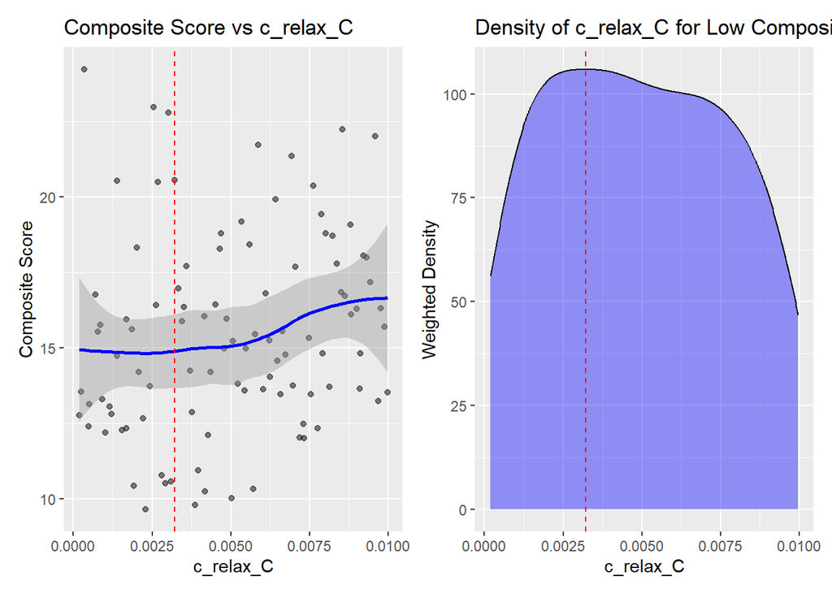

```r
  ##### FLake #####

    ## c_relax_C
    # Extract the computed density data from ggplot
    dens_data <- ggplot_build(
      ggplot(join_FLake, aes(x = c_relax_C)) +
        geom_density(aes(weight = 1 / score), fill = "blue", alpha = 0.4)
    )$data[[1]]

    # Find wind speed where density is maximized
    optimal_c_relax_C <- dens_data$x[which.max(dens_data$y)]


    a_c_relax_C = ggplot(join_FLake, aes(x = c_relax_C, y = score)) +
      geom_point(alpha = 0.5) +
      geom_smooth(method = "loess", color = "blue") +
      geom_vline(xintercept = optimal_c_relax_C, color = "red", linetype = "dashed") +
      labs(title = "Composite Score vs c_relax_C",
           x = "c_relax_C",
           y = "Composite Score")

    b_c_relax_C = ggplot(join_FLake, aes(x = c_relax_C)) +
      geom_density(aes(weight = 1 / score), fill = "blue", alpha = 0.4) +
      geom_vline(xintercept = optimal_c_relax_C, color = "red", linetype = "dashed") +
      labs(title = "Density of c_relax_C for Low Composite Score",
           x = "c_relax_C",
           y = "Weighted Density")

    a_c_relax_C+b_c_relax_C
```

```r
    print(optimal_c_relax_C)
```

```
## [1] 0.003212647
```

## Calibrated Model Run

Followingly, the ensemble was run with the calibrated parameters. It is suggested to set the parameter `nlev` to 6 for the model GOTM in the calibration to set the amount of layers that should be modelled to 0.3 m / 6 = 0.05m. This avoids the internal computation resulting in the output of only 2 layers. However, this did not avoid the lack of output at certain depths.

```r
config_file = "LakeEnsemblR_EERES_calibrated.yaml"
model = c("FLake","GOTM","Simstrat")
export_config(config_file = config_file, model = model)
```

```
##   depths wtemp
## 1   0.30 20.49
## 2   0.25 20.56
## 3   0.20 20.63
## 4   0.15 20.68
## 5   0.10 20.69
## 6   0.05 20.67
```

```r
run_ensemble(config_file = config_file, model = model, parallel=T, ncores=3, verbose = FALSE)
```

# Analysis

For a first glimpse, the heatmap of the temperature time series for each model and the observed temperature time series were plotted.

Some models show significant technical problems, when modelling ponds of such shallow depth. In this iteration, the GOTM model results only represent data up to a depth of 15cm.

```r
## Plot model output using gotmtools/ggplot2
# Extract names of all the variables in netCDF
ncdf <- 'output/ensemble_output.nc'

vars <- gotmtools::list_vars(ncdf)
vars # Print variables
```

```
## [1] "temp"    "w_level"
```

```r
p1 <- plot_heatmap(ncdf, var="temp")
```

```
## Extracted temp from output/ensemble_output.nc
```

```
##            [,1]
## short_name "temp"
## units      "degC"
## dimensions "lon lat z model member"
```

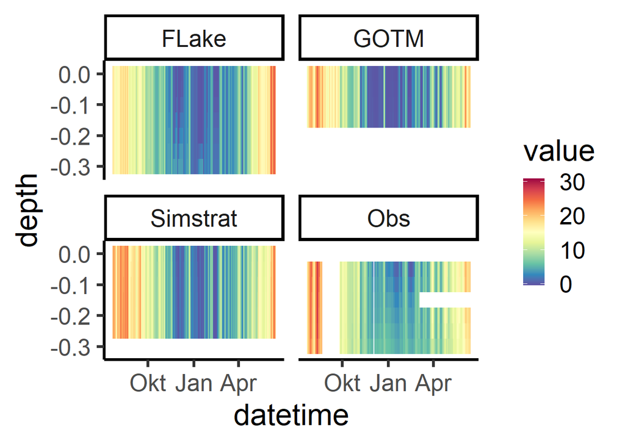

```r
# p1
# Change the theme and increase text size for saving
p1 <- p1 +
  theme_classic(base_size = 24) +
  scale_colour_gradientn(limits = c(0, 21),
                         colours = rev(RColorBrewer::brewer.pal(11, "Spectral")))
# Save as a png file
p1
```

```r
# ggsave('output/ensemble_heatmap.png', p1,  dpi = 300,width = 384,height = 280, units = 'mm')
```

We see that only the model FLake is able to provide results with a visible vertical stratification of water temperature. All models seem to show lower temperature than observed data. To further investigate this, we looked at the water temperature time series at each depth against the observed time series. The plotting of the temperature at sediment level using `depth=0.3` was not possible, probably for the reason already stated above.

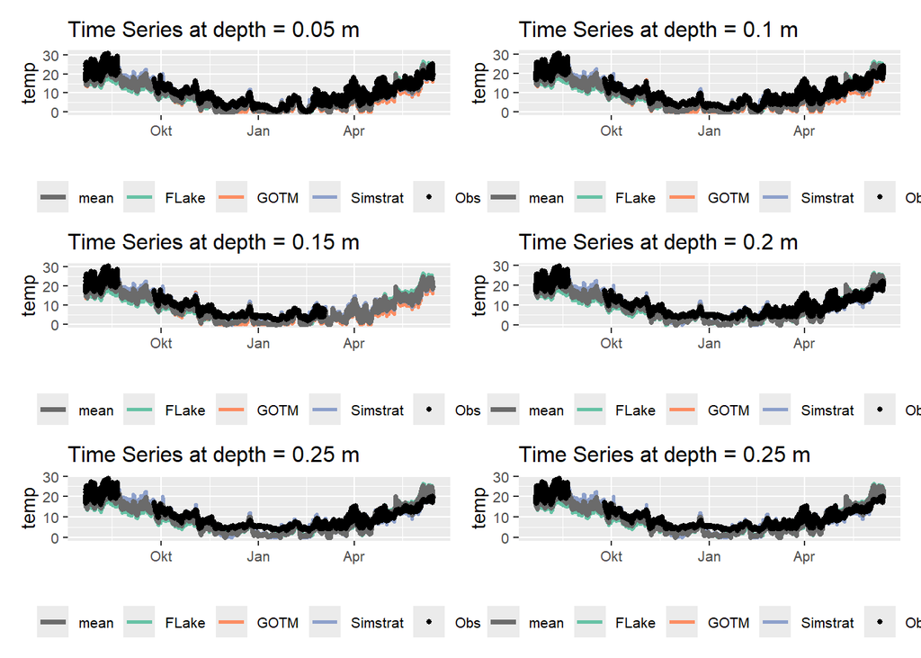

```r
# Plot ensemble means
plot5 = plot_ensemble(ncdf,model,var="temp", depth=0.05)
plot10 = plot_ensemble(ncdf,model,var="temp", depth=0.10)
plot15 = plot_ensemble(ncdf,model,var="temp", depth=0.15)
plot20 = plot_ensemble(ncdf,model,var="temp", depth=0.20)
plot25 = plot_ensemble(ncdf,model,var="temp", depth=0.25)

# following plotting might exceed the timeout limit of the graphics device.
# This can be avoided by rerunning the line of code.
p2 = plot5 + plot10 + plot15 + plot20 + plot25 + plot25 + plot_layout(ncol=2)
p2
```

```r
# ggsave('output/time_series_at_depths.png', p2,  dpi = 300,width = 280,height = 350, units = 'mm')
```

This can be inspected in even more detail by plotting the residuals at each depth using the `plot_resid` function.

```r
# Load watertemp from netCDF file as a list
wtemp <- load_var(ncdf = ncdf, var = "temp", return = "list")
```

```
## Extracted temp from output/ensemble_output.nc
```

```
##            [,1]
## short_name "temp"
## units      "degC"
## dimensions "lon lat z model member"
```

```r
names(wtemp)
```

```
## [1] "FLake"    "GOTM"     "Simstrat" "Obs"
```

```r
# Plot residual diagnostic plots
plots <- plot_resid(var_list = wtemp)
names(plots)
```

```
## [1] "obs_res"   "res_depth" "yday_res"  "res_dist"
```

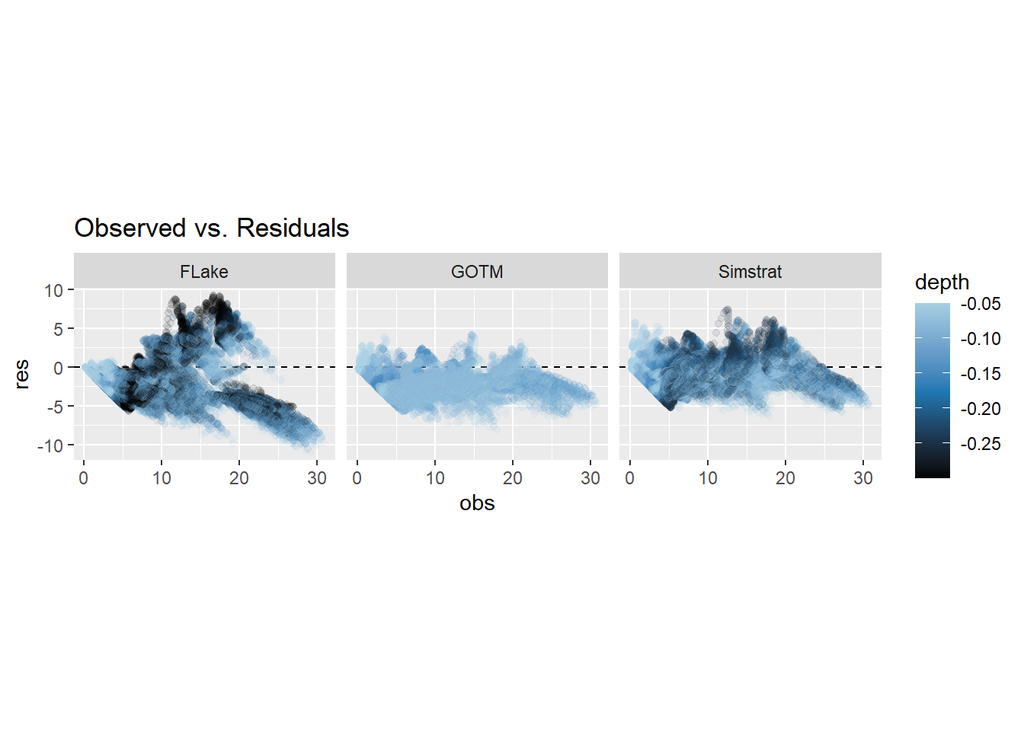

```r
# Plot residuals vs. observations
res_obs = plots[[1]]
res_obs
```

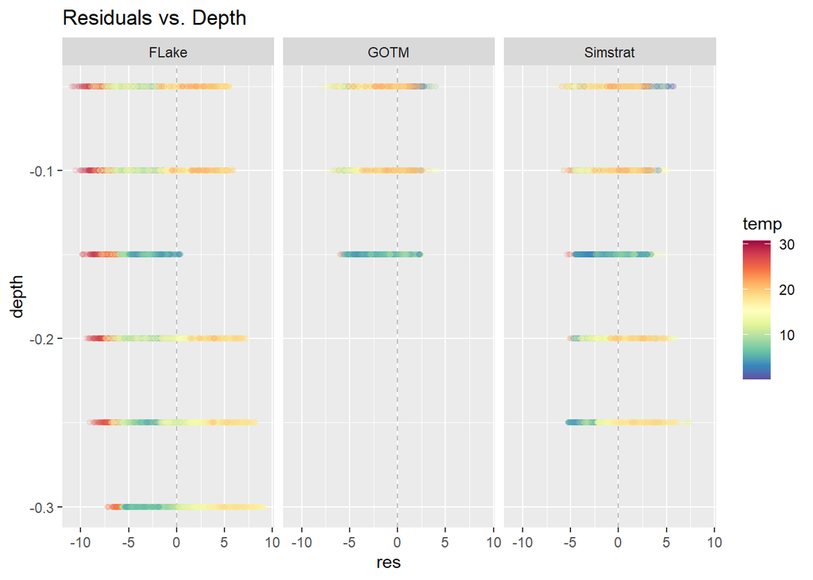

```r
# Plot residuals vs. depth
res_dep = plots[[2]]
res_dep
```

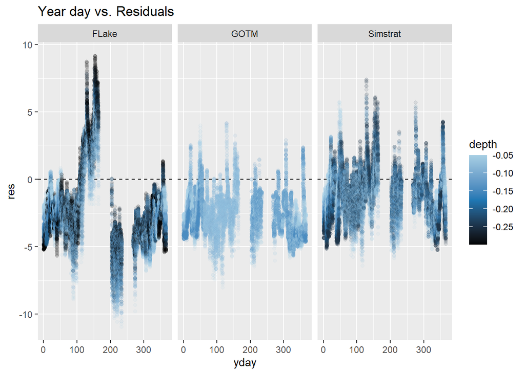

```r
# Plot residuals vs. day of year
res_doy = plots[[3]]
res_doy
```

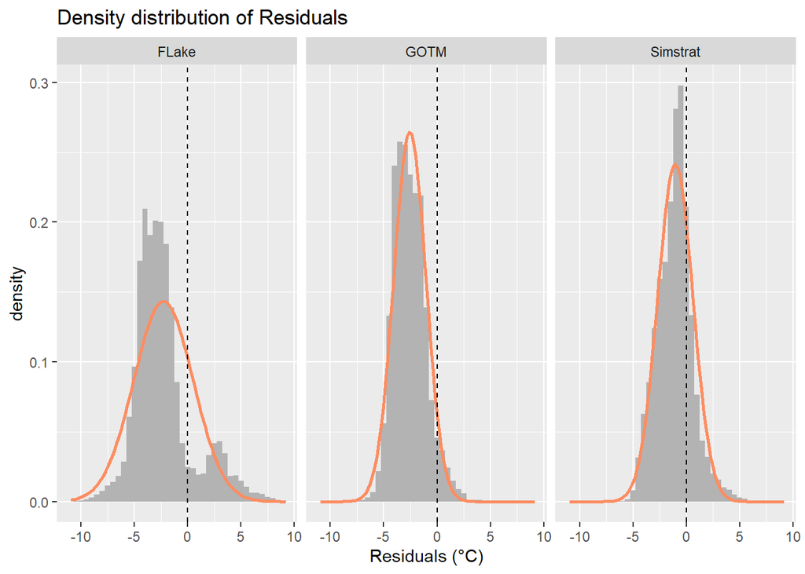

```r
# Plot residuals distributions
res_dist = plots[[4]]
res_dist
```

```r
ggsave("res_obs.png",res_obs,dpi=300,width=200,height=300,units="mm")
ggsave("res_doy.png",res_doy,dpi=300,width=200,height=300,units="mm")
ggsave("res_dep.png",res_dep,dpi=300,width=200,height=300,units="mm")
ggsave("res_dist.png",res_dist,dpi=300,width=200,height=300,units="mm")
```

The model fit can be extracted with the function `analyse_ncdf` as in the following code.

```r
# Analyse the netCDF output
out <- analyse_ncdf(ncdf, model = model, spin_up = 0)
names(out)
str <- out[["strat"]]
stats <- out[["stats"]]
```

```r
stats
```

```
##      model Pearson_r Variance_obs Variance_mod   SD_obs   SD_mod Covariance
## 1    FLake 0.9032928     36.04043     41.95187 6.003444 6.477108   35.12361
## 2     GOTM 0.9759995     41.81463     46.92658 6.466598 6.850483   43.23378
## 3 Simstrat 0.9704949     37.95024     44.89599 6.160471 6.700550   40.05938
##        Bias      MAE     RMSE       NSE lnlikelihood
## 1 -2.282729 3.229266 3.599434 0.6405169   -291696.85
## 2 -2.562256 2.672528 2.973014 0.7886192    -98743.36
## 3 -1.054773 1.555120 1.959592 0.8988149    -92149.10
```

The results match the analysis of the previous results, suggesting that Simstrat seems to most accurately represent the observed water temperature. Although the Pearson Correlation coefficient *r* of GOTM is slightly higher than the *r* of Simstrat, the more comprehensive Nash–Sutcliffe model efficiency coefficient (NSE) shows a more distinct measure of the capability to predict the water temperature, where Simstrat is about 14% more efficient than GOTM. These results might change when the results of all depths can be extracted from GOTM. The generally high *r* and differing model fit parameters support the statement, that the systematic discrepancies exceed the random discrepancies.

This work shows that the modelling of shallow pond systems is not readily applicable to the lake models in LakeEnsemblR. While two models generally failed to produce results for this scenario, three models could apply this scenario after a thorough preparation of the data and parameters. Despite the possibility to run these models, the pacakge inherits a lot of technical difficulties to represent the results using the internal analysis functions. The results of this work suggest, that when those problems are overcome, LakeEnsemblR is capable to deliver a wide foundation for further analysis of the random and systematic discrepancies of the predictions. Some parameters were suggested to be evaluated in more detail due to the impact in shallow pond systems.